[figure not shown]

PS-89

General Diagnostic Table

POWER ASSISTED SYSTEM (POWER STEERING)

1. NOISE & VIBRATION (HYDRAULIC TYPE)

CAUTION:

Do not keep the relief valve operated for five seconds or more at any time or inner parts of the oil

pump may be damaged due to rapid increase of fluid temperature.

NOTE:

• A grinding noise may be heard immediately after the engine start in extremely cold conditions. In this case,

if the noise goes off during warm up there is no abnormal function in the system. This is due to the fluid char-

acteristics in extremely cold condition.

• The oil pump normally makes a small whining noise due to its mechanism. Even if a noise is heard when

steering wheel is turned at stand still, there is no abnormal function in the system provided that the noise

eliminates when the vehicle is driving.

• When turning the steering wheel with the brake applied when the vehicle is parked, a screeching noise

may be generated by the brake disc and pads. This is not a fault in the steering system.

• There may be a small vibration around the steering devices when turning the steering wheel at standstill,

even though the component parts are operating properly.

Hydraulic systems are likely to generate this kind of vibration as well as working noise and fluid noise be-

cause of combined conditions, i.e., road surface and tire surface, engine speed and turning speed of steering

wheel, fluid temperature and braking condition.

These conditions do not indicate a problem in the system.

Confirm vibration by applying the parking brake on a concrete surface and turning the steering wheel from

slowly to rapidly, in steps.

Trouble Possible cause Corrective action

Hiss noise (continuous)

While engine is running.

Relief valve emits operating sound when steering wheel is

completely turned in either direction. (Do not keep this

condition for 5 seconds or more.)

Normal

Relief valve emits operating sound when steering wheel is

not turned. This means that the relief valve is defective.

Replace the oil pump.

Rattling noise (intermittent)

While engine is running.

Interference with adjacent parts

Check the clearance.

Correct if necessary.

<Ref. to PS-75, INSPECTION,

Pipe Assembly.>

Looseness of the installation of oil pump, oil tank, pump

bracket, gearbox or crossmember

Retighten.

Looseness of oil pump pulley or other pulley(s) Retighten.

Looseness of linkage, play of steering, improper tightening

(looseness) of suspension joint or steering column

Retighten or replace.

Sound generates from the inside of gearbox or oil pump.

Replace faulty parts in the gear-

box or oil pump.

Knocking

When turning steering wheel in

both directions with small angle

repeatedly at engine ON or OFF.

Excessive backlash

Loosened lock nut for adjusting backlash

Adjust and retighten.

Insufficient tightening or play in the tie-rod or tie-rod end Retighten or replace.

Grinding noise (continuous)

While engine is running.

Air in vane pump

Inspect and retighten the fluid

line connection.

Refill the fluid and vent air.

Vane pump seizing Replace the oil pump.

Oil pump pulley bearing seized Replace the oil pump.

Folded hose, flattened pipe Replace.

Squeal, squeak (intermittent or

continuous)

While engine is running.

Improper adjustment of pulley belt

Damaged or over tensioned pulley belt

Unequal length of pulley belts

Adjust or replace.

(Replace two belts as a set.)

Runout or dirty V-groove surface of oil pump pulley Clean or replace.

[figure not shown]

PS-90

General Diagnostic Table

POWER ASSISTED SYSTEM (POWER STEERING)

2. NOISE & VIBRATION (ELECTRIC TYPE)

NOTE:

• When turning the steering wheel with the brake applied when the vehicle is parked, a screeching noise

may be generated by the brake disc and pads. This is not a fault in the steering system.

• There may be a small vibration around the steering devices when turning the steering wheel at standstill,

even though the component parts are operating properly.

Sizzling noise (continuous)

While engine is running.

Fluid aeration

Fix the faulty part causing aera-

tion.

Replace the fluid and vent air.

Damaged pipe of gearbox Replace the pipe.

Faulty inside of hose or pipe

Flattened hose or pipe

Repair or replace.

Abnormal inside of oil tank Replace.

Removed oil tank cap Install cap.

Whistle (continuous)

While engine is running.

Faulty pipe of gearbox or faulty hose

Replace the faulty parts of the

gearbox or the hose.

Whine or growl (intermittent or

continuous)

While engine is running (with/

without steering turned).

Looseness of oil pump, oil pump bracket attachment Retighten.

Fault inside of oil pump or hose

Replace the oil pump or hose, if

the noise can be heard when

vehicle is running as well as

being stopped.

Torque converter growl, air conditioner compression growl

Remove the power steering pul-

ley belt and check.

Grinding noise (intermittent)

While engine is running (with the

steering turned).

Fault inside of gearbox

Replace the faulty parts of gear-

box.

Faulty bearing of the column assembly - steering Apply grease or replace.

Occurs when turning the steering wheel with brakes (ser-

vice or parking) applied.

If the noise goes off when brake

is released, it is normal.

Vibration

While engine is running (with/

without steering turned).

Engine speed is too low. Adjust, and notify customer.

Air in vane pump

Repair faulty part.

Vent air.

Damaged valve in oil pump or gearbox

Replace the faulty parts in gear-

box and oil pump.

Excessive play in steering, looseness of suspension parts Retighten.

Trouble Possible cause Corrective action

Rattling noise (intermittent)

While engine is running.

Interference with adjacent parts

Check the clearance.

Correct if necessary.

Looseness of linkage, play of steering, improper tightening

(looseness) of suspension joint or steering column

Retighten or replace.

Noise emitted from inside of the gearbox Replace the gearbox assembly.

Knocking

When turning steering wheel in

both directions with small angle

repeatedly at engine ON or OFF.

Excessive backlash

Loosened lock nut for adjusting backlash

Adjust the backlash. When the

noise remains after adjustment,

replace the gearbox assembly.

Insufficient tightening or play in the tie-rod or tie-rod end Retighten or replace.

Grinding noise (intermittent)

While engine is running. (While

operating the steering.)

Fault inside of gearbox Replace the gearbox assembly.

Faulty bearing of the column assembly - steering Apply grease or replace.

Occurs when turning the steering wheel with brakes (ser-

vice or parking) applied.

If the noise goes off when brake

is released, it is normal.

Vibration

While engine is running. (with/

without steering turned)

Excessive play in steering, looseness of suspension parts Retighten.

Trouble Possible cause Corrective action

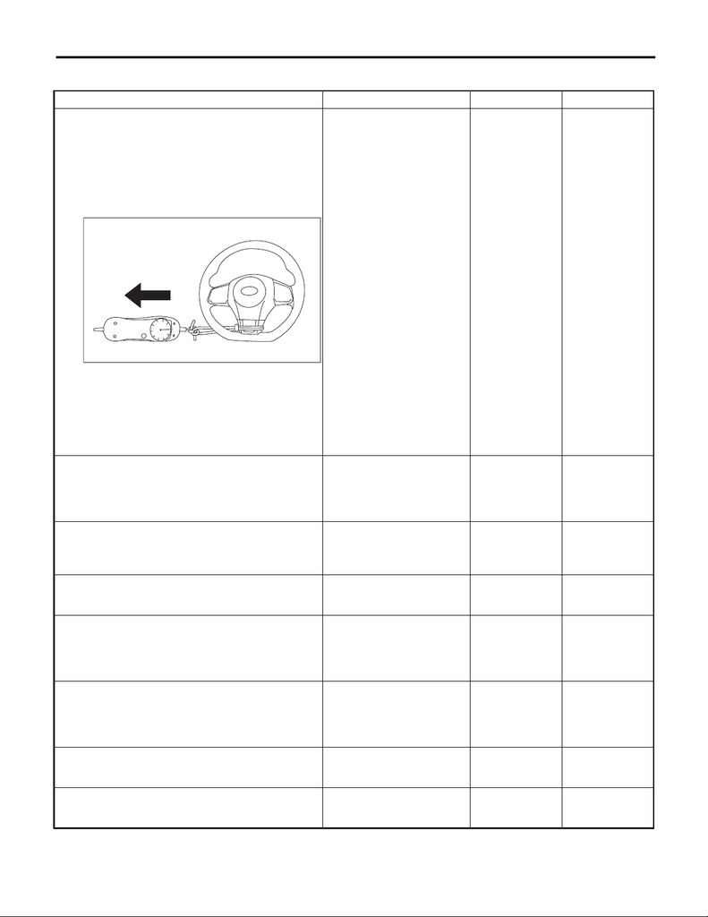

PS-91

General Diagnostic Table

POWER ASSISTED SYSTEM (POWER STEERING)

3. MEASUREMENT OF STEERING EFFORT (HYDRAULIC TYPE)

Step Check Yes No

1 CHECK STEERING EFFORT.

1) Stop the vehicle on paved road.

2) Start the engine.

3) Run the engine at idle.

4) Install a spring scale on the steering wheel.

5) Pull the spring scale at a right angle to the

steering wheel, and measure both right and left

steering wheel efforts.

NOTE:

When turning the steering more quickly than

necessary from a direction to the other direction

at an engine speed of 2,000 rpm or higher,

steering effort may be heavy. This is caused by

flow characteristic of the fluid in the oil pump

and is not a defect.

Is the steering effort less than

31 N (3.2 kgf, 7.0 lbf)?

Steering effort is

normal.

Go to step 2.

2 CHECK STEERING EFFORT.

1) Stop the engine and lift up the vehicle.

2) Pull the spring scale at a right angle to the

steering wheel, and measure both right and left

steering wheel efforts.

Is the steering effort less than

15 N (1.53 kgf, 3.4 lbf)?

Go to step 3. Perform the back-

lash adjustment.

3 CHECK STEERING WHEEL EFFORT.

1) Remove the universal joint assembly -

steering.

2) Measure the steering wheel effort.

Is the steering effort less than

2.26 N (0.23 kgf, 0.51 lbf)?

Go to step 4. Replace the col-

umn assembly -

steering.

4 CHECK STEERING WHEEL EFFORT.

Measure the steering wheel effort.

Is the difference of steering

effort between right and left

less than 20%?

Go to step 5. Replace the col-

umn assembly -

steering.

5 CHECK UNIVERSAL JOINT ASSEMBLY -

STEERING.

Measure the swing torque of the joint (yoke on

the column assembly - steering side). <Ref. to

PS-23, INSPECTION, Universal Joint.>

Is the swing torque of the uni-

versal joint assembly - steering

less than 7.3 N (0.74 kgf, 1.64

lbf)?

Go to step 6. Replace the uni-

versal joint assem-

bly - steering.

6 CHECK UNIVERSAL JOINT ASSEMBLY -

STEERING.

Measure the swing torque of the joint (yoke of

gearbox side). <Ref. to PS-23, INSPECTION,

Universal Joint.>

Is the swing torque of the uni-

versal joint assembly - steering

less than 3.8 N (0.39 kgf, 0.86

lbf)?

Go to step 7. Replace the uni-

versal joint assem-

bly - steering.

7 CHECK FRONT WHEEL.

Check the front wheels.

Does the front wheels have

unsteady revolution or rattling,

or does the brake drag?

Inspect, readjust

and replace if nec-

essary.

Go to step 8.

8 CHECK TIE-ROD ENDS.

Remove the tie-rod ends from housing.

Does the tie-rod ends have

unsteady revolution or rattling?

Inspect and

replace if neces-

sary.

Go to step 9.

PS-01723

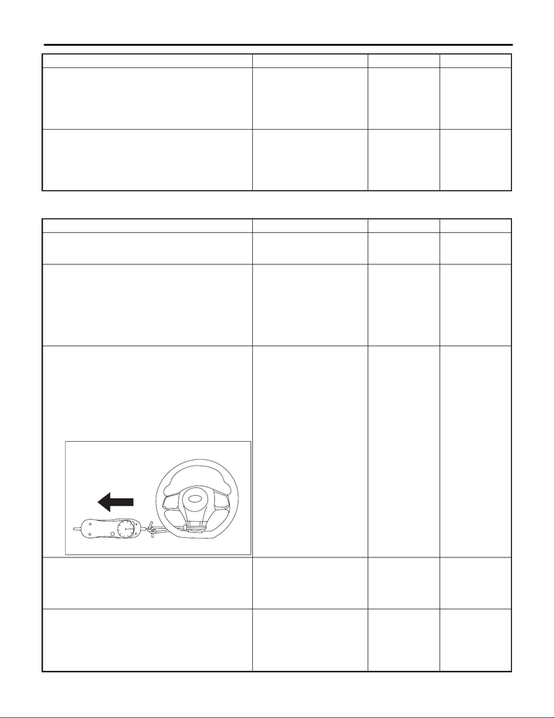

PS-92

General Diagnostic Table

POWER ASSISTED SYSTEM (POWER STEERING)

4. MEASUREMENT OF STEERING EFFORT (ELECTRIC TYPE)

9 CHECK GEARBOX.

Measure the rotating of gearbox.

<Ref. to PS-50, LIMIT, INSPECTION, Steering

Gearbox.>

Is the rotational resistance of

the steering gearbox less than

21 N (2.1 kgf, 4.7 lbf)? Is the dif-

ference between the right and

left rotational resistances less

than 20%?

Go to step 10. Readjust the back-

lash, and if ineffec-

tive, replace the

faulty parts.

10 CHECK GEARBOX.

Measure the sliding of gearbox.

<Ref. to PS-50, LIMIT, INSPECTION, Steering

Gearbox.>

Is the sliding resistance of the

steering gearbox less than 343

N (35 kgf, 77 lbf)? Is the differ-

ence between the right and left

sliding resistances less than

20%?

Steering effort is

normal.

Check the suspen-

sion.

Readjust the back-

lash, and if ineffec-

tive, replace the

faulty parts.

Step Check Yes No

1 CHECK STEERING WARNING LIGHT. Does the STEERING warning

light illuminate?

Read the DTC, and

inspect according

to it.

Go to step 2.

2 CHECK STEERING WARNING LIGHT.

1) Connect the Subaru Select Monitor, and

turn the steering wheel. (One lock to lock)

2) Check the “EPS operation flag” in the cur-

rent data.

Is the EPS operation flag nor-

mal without displaying any DTC

code?

Go to step 3. If the EPS opera-

tion flag is “Assist

limitation”, stop the

engine for approx.

30 minutes and

perform the proce-

dures from step 1

again.

3 CHECK STEERING EFFORT.

1) Stop the vehicle on paved road.

2) Set the tire air pressure to the specification.

3) Start the engine.

4) Run the engine at idle.

5) Install a spring scale on the steering wheel.

6) Pull the spring scale at a right angle to the

steering wheel, and measure both right and left

steering wheel efforts.

Is the steering effort less than

31 N (3.2 kgf, 7.0 lbf)?

Go to step 4. Go to step 8.

4 CHECK STEERING EFFORT.

1) Stop the engine.

2) Pull the spring scale at a right angle to the

steering wheel, and measure both right and left

steering wheel efforts.

Is the steering effort less than

294.2 N (30 kgf, 66.2 lbf)?

Go to step 5. Perform the

inspection or

adjustment around

the suspension

part.

5 CHECK TORQUE SENSOR OUTPUT VALUE.

1) Connect the Subaru Select Monitor.

2) Read the output of torque sensor voltage.

NOTE:

When measuring, place the steering wheel at

the center position.

Is the voltage 2.425 — 2.575

V?

Go to step 6. Replace the gear-

box assembly.

<Ref. to PS-56,

Electric Power

Steering Gear-

box.>

Step Check Yes No

PS-01723

[figure not shown]

PS-93

General Diagnostic Table

POWER ASSISTED SYSTEM (POWER STEERING)

6 CHECK TORQUE SENSOR OUTPUT VALUE.

1) Remove the universal joint assembly -

steering.

2) Connect the Subaru Select Monitor.

3) Read the output of torque sensor voltage.

Is the voltage 2.425 — 2.575

V?

Go to step 7. Replace the gear-

box assembly.

<Ref. to PS-56,

Electric Power

Steering Gear-

box.>

7 CHECK TORQUE SENSOR OUTPUT VALUE.

1) Remove the universal joint assembly -

steering.

NOTE:

Check that the universal joint assembly - steer-

ing moves up and down smoothly without in-

stalling the bolt. Then tighten the bolts first on

the gearbox side and then on the column shaft

side.

2) Connect the Subaru Select Monitor.

3) Read the output of torque sensor voltage.

Is the voltage 2.425 — 2.575

V?

Go to step 8. Check the univer-

sal joint assembly -

steering. <Ref. to

PS-56, Electric

Power Steering

Gearbox.>

8 CHECK STEERING WHEEL EFFORT.

1) Remove the universal joint assembly -

steering.

2) Measure the steering wheel effort.

Is the steering effort less than

2.26 N (0.23 kgf, 0.51 lbf)?

Go to step 9. Replace the col-

umn assembly -

steering. <Ref. to

PS-56, Electric

Power Steering

Gearbox.>

9 CHECK STEERING WHEEL EFFORT.

Measure the steering wheel effort.

Is the difference of steering

effort between right and left

less than 20%?

Go to step 10. Replace the col-

umn assembly -

steering. <Ref. to

PS-25, Steering

Column.>

10 CHECK UNIVERSAL JOINT ASSEMBLY -

STEERING.

Measure the swing torque of joint. (Yoke of col-

umn assembly - steering side) <Ref. to PS-23,

INSPECTION, Universal Joint.>

Is the swing torque of the uni-

versal joint assembly - steering

less than 8.1 N (0.81 kgf, 1.84

lbf)?

Go to step 11. Replace the uni-

versal joint assem-

bly - steering with a

new part. <Ref. to

PS-21, Universal

Joint.>

11 CHECK UNIVERSAL JOINT ASSEMBLY -

STEERING.

Measure the swing torque of joint. (Yoke of

gearbox side) <Ref. to PS-23, INSPECTION,

Universal Joint.>

Is the swing torque of the uni-

versal joint assembly - steering

less than 6.8 N (0.68 kgf, 1.54

lbf)?

Go to step 12. Replace the uni-

versal joint assem-

bly - steering with a

new part. <Ref. to

PS-21, Universal

Joint.>

12 CHECK FRONT WHEEL.

Check the front wheels.

Does the front wheels have

unsteady revolution or rattling,

or does the brake drag?

Inspect, readjust

and replace if nec-

essary.

Go to step 13.

13 CHECK TIE-ROD ENDS.

Remove the tie-rod ends.

Does the tie-rod ends of sus-

pension have unsteady revolu-

tion or rattling?

Inspect and

replace if neces-

sary.

Go to step 14.

14 CHECK BALL JOINT.

Remove the ball joint.

Does the ball joints of suspen-

sion have unsteady revolution

or rattling?

Inspect and

replace if neces-

sary.

Go to step 15.

15 CHECK GEARBOX.

Measure the rotating of gearbox.

<Ref. to PS-65, LIMIT, INSPECTION, Electric

Power Steering Gearbox.>

Is the turn resistance of the

steering gearbox less than 18 N

(1.8 kgf, 4.0 lbf)? Is the differ-

ence between the right and left

rotational resistances less than

20%?

Go to step 16. Replace the gear-

box assembly.

<Ref. to PS-56,

Electric Power

Steering Gear-

box.>

Step Check Yes No

[figure not shown]

PS-94

General Diagnostic Table

POWER ASSISTED SYSTEM (POWER STEERING)

5. CLEARANCE CHECK (HYDRAULIC TYPE)

This table lists various clearances that must be correctly adjusted to ensure the normal vehicle driving with-

out interfering noise, or any other faults.

16 CHECK GEARBOX.

Measure the sliding of gearbox.

Is the sliding resistance of the

steering gearbox less than 360

N (36.7 kgf, 80.9 lbf)? Is the dif-

ference between the right and

left sliding resistances less than

20%?

Steering effort is

normal.

Replace the gear-

box assembly.

<Ref. to PS-56,

Electric Power

Steering Gear-

box.>

Location Minimum allowance mm (in)

(1) Crossmember to hose ASSY 3 (0.12)

(2) Front exhaust pipe to hose ASSY 15 (0.59)

(3) Front frame side to hose ASSY 10 (0.39)

(4) Master cylinder to return hose 10 (0.39)

(5) Master cylinder to hose clip 10 (0.39)

(6) VDC H/U to hose ASSY 5 (0.20)

(7) Air cleaner to hose ASSY 5 (0.20)

(8) Air boot to hose ASSY 10 (0.39)

(9) Air cleaner hose to hose ASSY 10 (0.39)

(10) Brake pipe to return hose 10 (0.39)

(11) Front suspension bracket to return hose 5 (0.20)

(12) Front wheel apron to return hose 5 (0.20)

(13) VDC H/U bracket to suction hose 5 (0.20)

(14) Air cleaner case to suction hose 5 (0.20)

(15) Air intake duct to suction hose 10 (0.39)

(16) Air duct to suction hose 10 (0.39)

(17) Front wheel apron to reservoir tank 5 (0.20)

(18) VDC H/U to reserve tank 5 (0.20)

(19) Valve housing to DOJ (MT model) 12 (0.47)

(20) Valve housing to crossmember (hole) 1 (0.04)

(21) Cannon mount to crossmember There must be no contact

(22) Pipe to crossmember 5 (0.20)

(23) Pipe to stabilizer 15 (0.59)

(24) Pipe to exhaust pipe 18 (0.71)

(25) Tie-rod end to brake dust cover 2.5 (0.10)

(26) Universal joint column side yoke to master cylinder (closest point of approach when the

universal joint turns by 360°)

5 (0.20)

Step Check Yes No

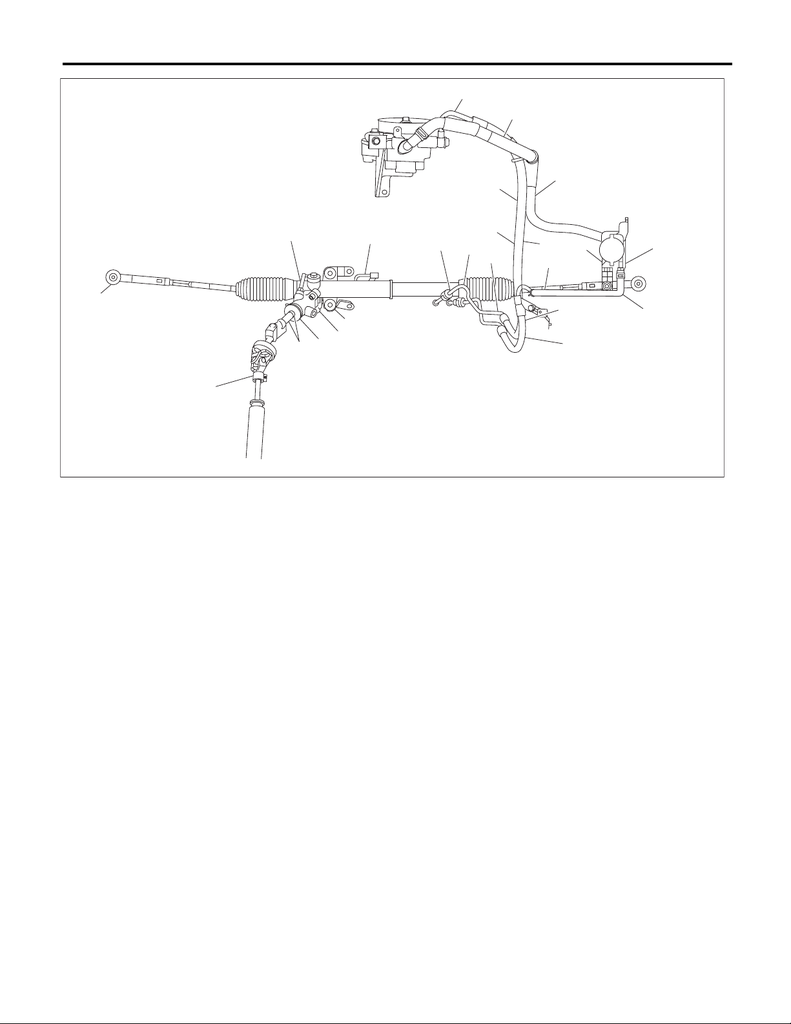

PS-95

General Diagnostic Table

POWER ASSISTED SYSTEM (POWER STEERING)

PS-01762

(1)

(5)

(12)

(17)(18)

(4)

(10),(11)

(9),(13)

(3)

(24)

(22)

(6)

(2)

(23)

(7),(8)

(19)

(20)

(21)

(14)

(16)

(15)

(26)

(25)

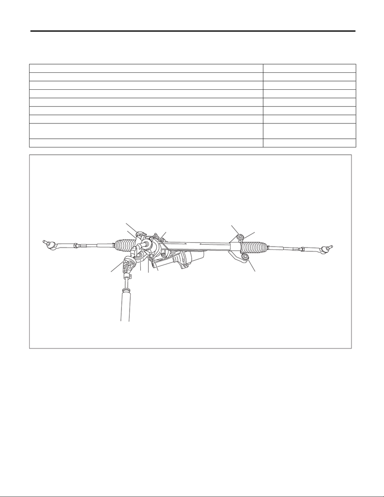

PS-96

General Diagnostic Table

POWER ASSISTED SYSTEM (POWER STEERING)

6. CLEARANCE CHECK (ELECTRIC TYPE)

This table lists various clearances that must be correctly adjusted to ensure the normal vehicle driving with-

out interfering noise, or any other faults.

Location Minimum allowance mm (in)

(1) Stub housing to DOJ (MT model) 15 (0.59)

(2) Torque sensor to crossmember 5 (0.20)

(3) Cannon mount to crossmember There must be no contact

(4) Cannon mount to crossmember 3 (0.12)

(5) Stub housing to engine mount 15 (0.59)

(6) Canon mount to exhaust pipe 15 (0.59)

(7) Universal joint column side yoke to master cylinder (closest point of approach when the

universal joint turns by 360°)

5 (0.20)

(8) Wheel housing to exhaust pipe 13 (0.51)

PS-00910

(8)

(1)

(3)

(2)

(6)

(4)

(5)

(3)

(4)

(7)

[figure not shown]

POWER ASSISTED SYSTEM

(POWER STEERING) (DIAGNOSTICS)

PS(diag)

Page

1. Basic Diagnostic Procedure .......................................................................2

2. Check List for Interview ..............................................................................4

3. General Description ...................................................................................7

4. Electrical Component Location ..................................................................8

5. Control Module I/O Signal ..........................................................................9

6. Subaru Select Monitor ..............................................................................11

7. Read Diagnostic Trouble Code (DTC) .....................................................16

8. Inspection Mode .......................................................................................17

9. Clear Memory Mode .................................................................................18

10. STEERING Warning Light ........................................................................19

11. List of Diagnostic Trouble Code (DTC) ....................................................22

12. Diagnostic Procedure with Diagnostic Trouble Code (DTC) ....................24